# Record Data Cleaning

### Introduction

In this page, I will demonstrate the methods I used to clean the raw record data I collected for this project, as well as the reasons why I chose to use these methods due to the purpose of transparency. The code that I wrote to clean the data can be found here: [Data Cleaning Code](https://github.com/anly501/anly-501-project-yeyaxin1103/tree/main/codes/02-data-cleaning)

### Data 1: Fertility Rate, Total (Births per Woman)

#### Language Used for Cleaning: R

#### Data Source: [The World Bank](https://data.worldbank.org/indicator/SP.DYN.TFRT.IN?end=2020&most_recent_value_desc=false&start=1960&view=chart&year=20200)

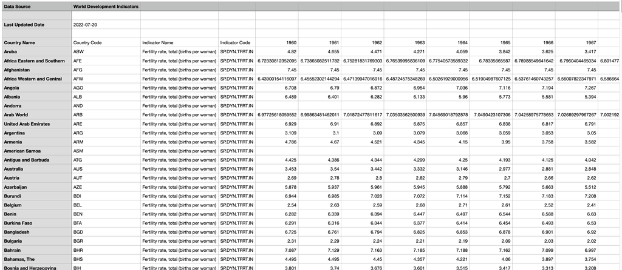

Fertility Rate Raw Data Snapshot

By looking at the snapshot of this data set, we can notice several formatting problems which make it unclean:

- Value as attributes: the columns 1960 - 2021 should be the value of the attribute year
- Empty column: the column 2021 has no values
- Extra rows: extra rows above the column names
- Unnecessary columns: columns Indicator Code and Indicator Name are not needed for future analysis
- Inconsistent numeric digits: some numeric values have more digits than the others

Therefore, I performed the following operations to clean the data set:

1. removing the rows above attribute names in the data set where data source and last updated date were recorded
2. replacing spaces with underscore mark in column names
3. removing attribute “Indicator Name”, its value is “Fertility rate, total (births per woman)”, which is something we already know and not useful for any future quantitative or qualitative analysis
4. removing attribute “Indicator Code”, the value of which is the code of “Indicator Name”, and is not needed for any future analysis
5. removing the column ‘2021’ because it has no value recorded
6. melting the data from column 1960 to 2020 and naming the new column ‘year’, and naming its value column “FertilityRate”
7. limiting the decimal digits to 3 for the columnn “FertilityRate”

The fertility rate data set after cleaning looks like this:

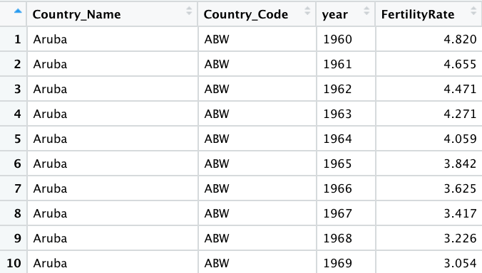

It’s worth noting that the fertility rate values of some countries/regions are missing. The countries and the regions that contain missing fertility rate values are:  
*Andorra, American Samoa, Bermuda, Curacaom, Cayman Islands, Dominica, Faroe Islands, Gibraltar, Greenland, Isle of Man, Not classified, St. Kitts and Nevis, Liechtenstein, Luxembourg, St. Martin (French part), Monaco, Marshall Islands, Northern Mariana Islands, Nauru, Palau, West Bank and Gaza, San Marino, Serbia, Sint Maarten (Dutch part), Seychelles, Turks and Caicos Islands, Tuvalu, British Virgin Islands, Kosovo.*

I will replace these values with the mean fertility rate of each country/region. If a country/region has no fertility rate values recorded at all, I will remove the country from the data set. I consider using this approach because by looking at the country or region names which have fertility rate data missing, we can tell that they are mainly the regions where no heavy populations reside in. There are no East Asian countries/regions nor world major economies included as well. Therefore, it is safe to say that excluding these regions which has no fertility rate data available would not create a huge impact on this project research.

This data source also contains another data set which provides the country code and region classification information: country code, region, income group (of the country), special notes, and table name (country name).

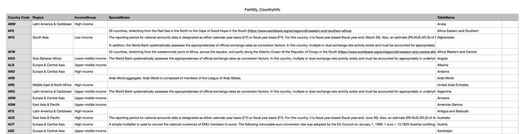

I left joined the clean fertility rate table with this country information table and only kept the country income group and region attributes from the country information table since they might be useful for the analysis next step. The other attributes such as Special Notes and TableName are either redundant or useless for the study, therefore they will be excluded.

The joined new data (raw) set looks like this:

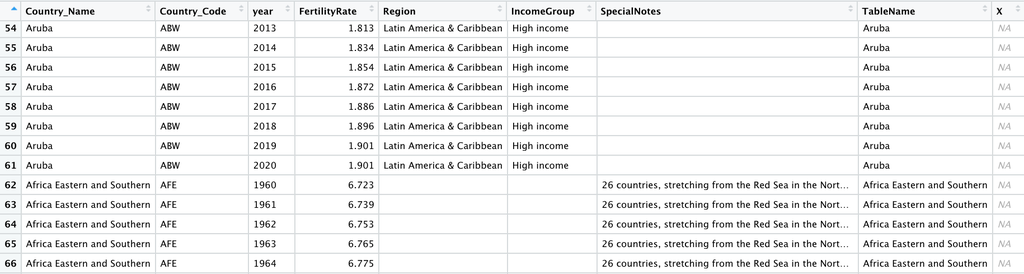

The countries/regions below are the ones without any available fertility rate data from 1960 to 2020 and will be excluded from the data set: *American Samoa, Cayman Islands, Gibraltar, Monaco, Northern Mariana Islands, Nauru, Turks and Caicos Islands, Tuvalu, British Virgin Islands*

The missing fertility rate values of the other countries/regions with partial missing data will be replaced with their mean fertility rate.

For the joined new data set, I performed the following operations to clean the data set:

1. renaming columns
2. removing SpecialNotes, X, TableName because they are not useful and redundant
3. replacing the fertility rate of the countries/regions with partial fertility values missing
4. removing the records of countries/regions without any fertility rate data available
5. changing the income group of the country Venezuela to ‘Unclassified’ due to a lack of data in recent years [source of the classification](https://blogs.worldbank.org/opendata/new-world-bank-country-classifications-income-level-2021-2022)
6. exporting data to the 01-modified-data folder inside data folder of the project

Finally, a snapshot of the new clean fertility rate data set (final) looks like this:

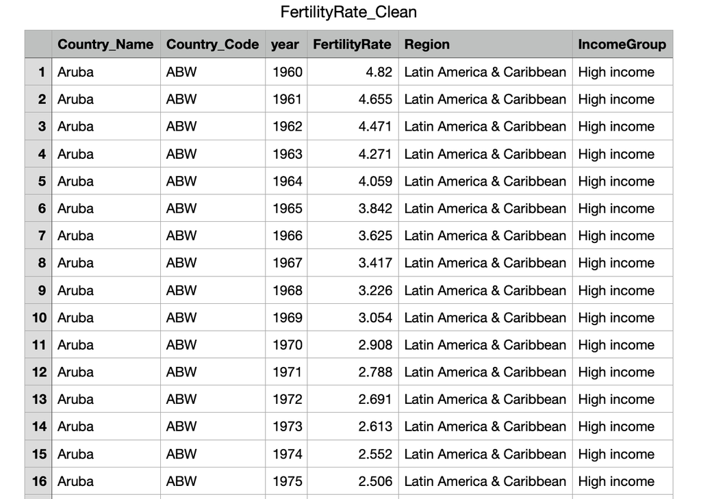